# Flourishing

A framework to improve lives

2019-03-26

# Why we do what we do

This framework comes from a simple starting point: the intent of supports and services is to help each person to flourish, to achieve a better life.

That belief is, thankfully, not a new one. It aligns with the MDHHS person-centered planning policy, which begins by stating that:

MDHHS BHDDA Person-Centered Planning Policy (June 5, 2017), p. 1

> *The purpose of the community mental health system is to support adults and children… to live successfully in their communities — achieving community inclusion and participation, independence, and productivity [and to] to identify and achieve their personal goals.*

The framework defined below is an attempt to apply these longstanding and fundamental values in a way that allows for consistent definitions, implementation, and evaluation.

# What do we mean by ‘a better life’?

People have been asking themselves what it means to live a good life for thousands of years, and it is among the most crucial questions for each of us to answer. Here, we will refer to the characteristics that make up a good life as *quality of life*, or QOL for short, relying primarily on contemporary research to arrive at a common and usable definition.

The philosopher Aristotle defined the highest good of human life as happiness, or flourishing (*eudaimonia*). cf. *Nicomachean Ethics*

## What makes a good definition?

If we are going to try to define quality of life, it is important that our definition gets a few things right:

These considerations are drawn from [Cummins, R. (2005). Moving from the quality of life concept to a theory. JIDR, 49(10), 699-706](https://www.ncbi.nlm.nih.gov/pubmed/16162114).

1. *Multiple dimensions*. A good life can only be described using multiple dimensions. These are influenced by personal factors, environmental factors, and the interaction between those factors.
2. *Broad enough for everyone*. We should each want to apply the definition to our own lives. The basic characteristics of a good life are the same for all people, regardless of culture, gender, disability, etc.
3. *Both subjective and objective*. People have different priorities. While a definition can point to objective facts related to QoL, it must include the point-of-view of the person who is living their life from day to day. Each dimension of a QoL model may have both objectively and subjectively defined indicators.

Taken together, the criteria listed above seek to balance the abstract with the specific to arrive at a definition which is well-rounded and understandable.

## What makes a better life?

Keeping our key requirements in mind, we can draw from the broad reservoir of studies on QoL to find frameworks which are multi-dimensional, cross-culturally relevant, and which provide both subjective and objective indicators.

See systematic review of HRQoL recommending addition of individual and environmental characteristics: [Bakas, T., et al. (2012)](https://www.ncbi.nlm.nih.gov/pmc/articles/PMC3548743/).

See [Schalock, R., et al. (2005).](https://www.researchgate.net/profile/Mian_Wang4/publication/7801771_Cross-Cultural_Study_of_Quality_of_Life_Indicators/links/0deec52df448eac34d000000/Cross-Cultural-Study-of-Quality-of-Life-Indicators.pdf).

Below is a potential model listing essential dimensions of QoL:

QoL Dimensions

| Area | Dimension | Example Indicators |
| --- | --- | --- |
| Independence | Personal development | Education status, personal skills, ADLs, IADLs |
|  | Self-determination | Choices, autonomy, personal control, goals |
| Social participation | Interpersonal relations | Social networks, activities, relationships |
|  | Social inclusion | Community integration, participation, roles |
|  | Rights | Human (respect/dignity, equality), Legal |
| Well-being | Emotional well-being | Safety, positive experiences, self-concept, stress |
|  | Physical well-being | Health, nutrition, recreation/physical exertion |
|  | Material well-being | Financial status, employment, housing, possessions |

Please note that the framework listed above is one of many potential models, each of which contains many of the same basic dimensions, and many were developed with populations having specific conditions. Some other broad-based models for review include:

- The [World Health Organization Quality of Life (WHOQOL)](https://apps.who.int/iris/bitstream/handle/10665/77932/WHO_HIS_HSI_Rev.2012.03_eng.pdf?sequence=1&isAllowed=y) domains.
- The [Eurostat QoL indicators](https://ec.europa.eu/eurostat/statistics-explained/index.php?title=Quality_of_life_indicators) show an example of QoL domains applied for entire countries alongside financial indicators such as gross domestic product (GDP).
- Healthy People 2020 has selected a subset of measures for monitoring health-related QoL and well-being in the United States. See their [Foundation Health Measure Report: Health-Related QoL and Well-Being](https://www.healthypeople.gov/sites/default/files/HRQoLWBFullReport.pdf).

# Benefits of a QoL Perspective

## What other frameworks exist?

One might well ask: *Is quality of life the only potential framework that we could use to measure improvement?* The answer is *No*, so it is worth discussing other options and briefly reviewing the attributes of each. Other options include:

- *Symptom reduction*: Measurement of reduction in symptoms related to specific diagnosable conditions. Symptom scales such as the [PHQ-9](https://www.phqscreeners.com/sites/g/files/g10049256/f/201412/PHQ-9_English.pdf), GAD-7 and other tools have commonly been used to measure the impact of treatments on specific conditions, but they are more challenging to use for people with multiple co-occuring conditions (MCC).
- *Improving functional status*: Most currently used assessment tools address functional status, measuring the impact of various conditions on broader life areas in terms of their impact on functional ability. These are broader than symptom scales, and can detect the impact of various symptoms on a particular functional domain.
- *Health-related quality of life (HRQoL)*: HRQoL addresses a subset of QoL domains which are related to perceived physical and mental health. These models typically exclude non-medical areas such as education or rights, focusing on physical domains like ‘mobility’.

## Why is a quality of life framework better than others?

A QoL approach has the following benefits over the approaches mentioned above:

**Strengths-based**: A QoL approach asks people what they want their lives to be and encourages them to work toward that vision. Rather than focusing on needs or deficits, it aspires to use a person’s strengths to improve his or her life.

See the MDHHS PCP Policy value that “The PCP approach identifies the person’s strengths, goals, choices… and desired outcomes.” (p. 4)

**Inclusive**: Instruments and measures from each of the other areas can be used as a part of the QoL framework, since it is broad enough to include each of these areas, and they each contribute to it. A QoL approach does not neglect the value of functional gains or symptom reduction, but values these as contributors to overall quality of life. For instance, if a person experiences an alleviation of their depressive symptoms using the PHQ-9, this would be seen as contributing toward the individual’s QoL in the area of ‘Emotional Well-being’.

**Contextual**: An approach which focuses on only a portion of an individual’s life, such as mobility or anxiety symptoms, is likely to miss out on the bigger picture. It may also inadvertently create siloes among the individuals supporting the person. For instance, more recent evaluations have criticized the HRQoL approach as failing to “sufficient emphasis on mental and social domains…that are essential to people.” The broader focus on QoL which is proposed here is aligned with our evolving understanding of several areas, each of which stresses the critical relationship between each of us and our communities and surroundings:

Read [Pietersma, S., et al. (2013)](https://www.ncbi.nlm.nih.gov/pmc/articles/PMC4031380/) regarding domains of quality of life.

- *Social Determinants of Health* (SDoH): A vast and growing body of [research](https://www.cdc.gov/socialdeterminants/research/index.htm) indicates that the places and conditions in which we live are intrinsically tied to the quality of our lives and the likelihood of achieving positive outcomes from the supports and services we receive.
- *Trauma-Informed Care*: More and more models for service provision, informed by research and by the lived experience of trauma survivors, are founded on the recognition that adverse events in our relationships and in our lived environment can have a profound and lifelong impact on our lives.

  For a recent review of these models, see: [Purtle, J. (2018). Trauma, Violence, & Abuse](https://www.ncbi.nlm.nih.gov/pubmed/30079827).
- *Supports Paradigm*: A model, prevalent in the IDD supports system, that views a person’s functioning as the match between their individual capacity and the environment in which they are expected to live and work. In this model, supports are viewed as a way to supplement the persons strengths and to help match those to the person’s environment.

  See [Thompson, et al. (2009)](https://www.ncbi.nlm.nih.gov/pubmed/19368481) on conceptualizing support needs.

# Person-Centered Everything

The collective effect of our needs and environments has a profound impact on society, but the primary catalyst for transformation is at the level of the individual person. This is the profound insight of *person-centered planning* (PCP), which has long been the cornerstone of Michigan policy related to behavioral health services and supports.

See the Michigan Mental Health Code, [Act 258 of 1974, Section 330.1712](http://legislature.mi.gov/doc.aspx?mcl-330-1712).

Despite the central position of PCP to the Medicaid services system in Michigan, in practice it has often been relegated to the planning meeting itself and the preparation for that meeting: ensuring inclusion of family and friends, personal involvement, etc. While the act of developing a plan remains a cornerstone of the process, it is only the first step of what is needed to truly achieve one’s goals.

Part of the focus on the meeting is due to the auditing focus on the plan document: an instance of *what is measured, is addressed*.

## Person-Centered *Planning-Doing-Checking-Acting*

The need for the PCP process to extend beyond the PCP meetings and to direct all services and supports is already recognized within state policy, which indicates that:

MDHHS BHDDA Person-Centered Planning Policy (June 5, 2017), p. 1

> *through PCP, a person is engaged in decision-making, problem solving, monitoring progress, and making needed adjustments to goals and supports and services provided in a timely manner.*

If we want to understand whether an individual person’s plan is supporting their goals, it is necessary to have a strategy to measure improvement in the person’s desired areas of focus. Such measurement-based approaches have been gaining traction in their use across populations.

[Shalock, et al. (2018)](https://aaidd.org/docs/default-source/sis-docs/changes-in-the-field.pdf?sfvrsn=cd8b3021_0) note “an increased emphasis on… conducting outcome evaluation… to assess the degree to which personal goals, positive changes, or benefits have been achieved” in IDD planning.

Framing the intent of supports and services as improving personal quality of life through person-centered planning also creates a natural bridge to using well-tested quality improvement processes at the individual level. Perhaps the most applicable of these is the *Plan-Do-Check-Act* (PDCA) cycle, which involves each element of the broad scope of PCP defined above. The PDCA cycle has already been successfully incorporated into the supports and treatment planning process for people with varying conditions and needs, from intellectual and developmental disabilities, to mental illness, to physical health concerns.

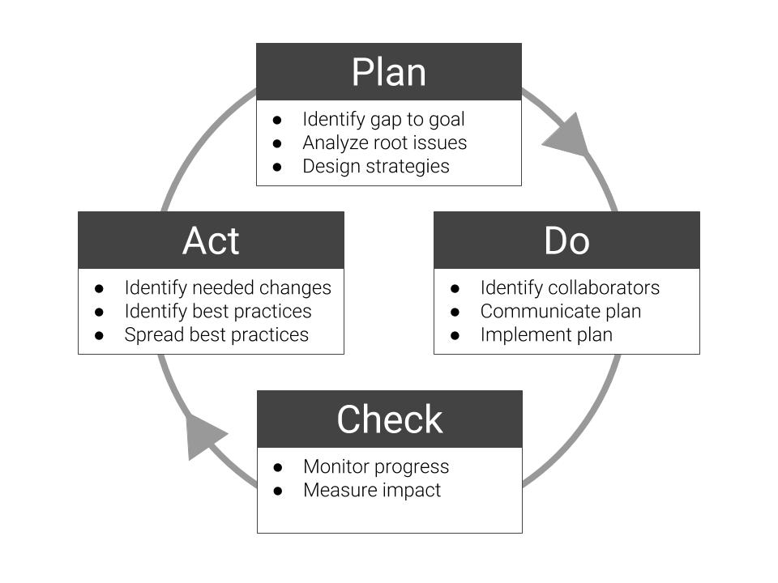

The table below illustrates the relationship between the PDCA process and a fuller definition of the PCP process:

Alignment of PDCA and PCP

| Factor | Plan | Do | Check | Act |
| --- | --- | --- | --- | --- |
| *Questions* | What is your life like? | What are you working on? | Is life better? | What next? |
|  | What do you want to pursue? | How are supports provided? |  | How to improve approach? |
|  | What supports do you need? | Where do you live/work? |  |  |
| *Activities* | Identify QoL | Work on plan | Check QoL | Revise plan |
|  | Assess needs | Coordinate services | Reassess needs | (Repeat cycle) |
|  | Develop plan |  |  |  |
| *Quality area* | Structure | Process | Outcome | (Re)structure |

While there are various other rubrics related to learning and improvement, PDCA has been selected here because of its use of ‘planning’ language, its simplicity, and its familiarity among behavioral healthcare providers and funders. Note that, while the questions above can be tied to various data-points, it is more important that they should be conversational: founded upon an ongoing process of personal striving for improvement.

## Person-Centered Design

When supports and services are viewed as a way to reach a goal, rather than a goal by themselves, creative uses of services and supports are more likely. Far from leading to a ‘cookie-cutter’ approach where `Condition X = Service Y`, using QoL information in the *planning* portion of the process allows people to:

- clearly identify gaps between where they are and where they want to be
- identify reasons why those gaps exist
- design new approaches to bridge those gaps

# Framework for Measurement

## Scope

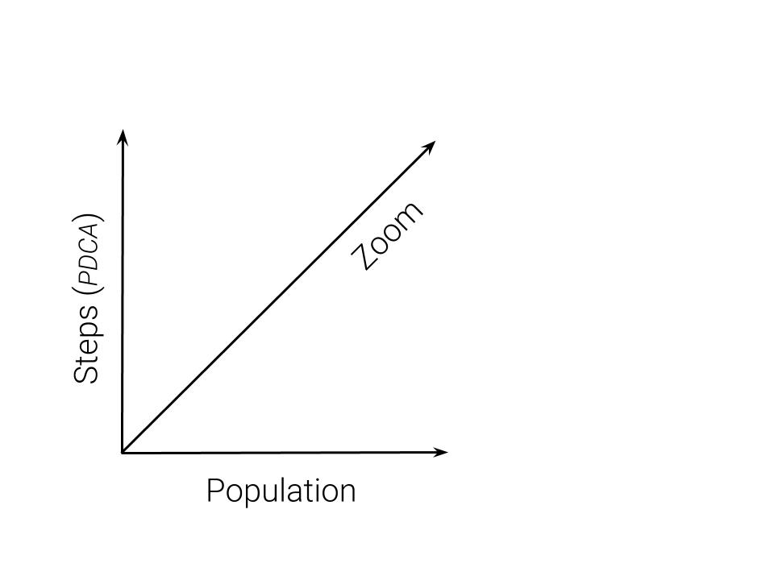

Scope of framework

A conceptual framework as comprehensive as the one we are proposing runs the risk of becoming overwhelmingly complex and unwieldy to implement. So, before diving into any details, we want to begin by sketching out a simple way to think about the scope of the framework required to systematically measure person-centered planning and its impact of quality of life. Having a definition of scope can help us answer questions such as:

- What types of data are included, and what types of measures?
- How will we know when the framework is fully implemented?
- Does this fit with other work that we are doing?

We can define the scope of the framework using three-dimensions (*depth, breadth, and height*) as defined below:

Those not geometrically inclined might want to think of “*the depth and breadth and height*” from [this sonnet](https://www.poetryfoundation.org/poems/43742/sonnets-from-the-portuguese-43-how-do-i-love-thee-let-me-count-the-ways)

**Depth** (a.k.a. *Zoom*): Does the framework allow for understanding at various levels of ‘resolution’, from the most immediate (i.e. *the individual person*) to the aggregate (i.e. *the population*) and other levels inbetween (e.g. *the organization, team, etc.*)?

**Breadth** (a.k.a. *Population*): Can the framework apply to all people who are planning to improve their lives with the help of services and supports?

I.e., to all ‘populations’ around which systems have been developed (*SMI, SED, IDD, SUD, etc.*). Since different data exists for each group, evaluating alignment is key.

**Height** (a.k.a. *Steps*): Does the framework allow for understanding of each of the steps in the person-centered PDCA process discussed above?

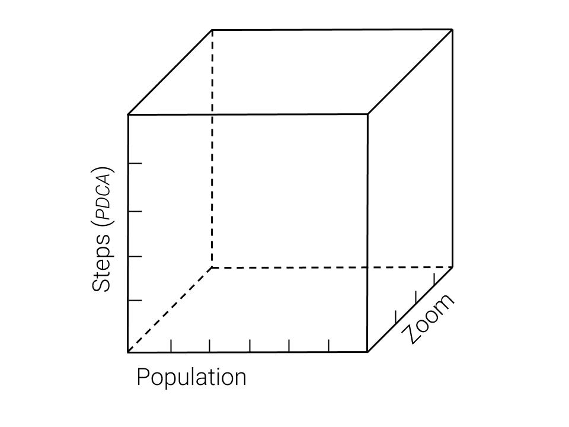

If it was a cube…

If we think about the framework as a cube made of these three dimensions, then developing the measurement framework can begin by making certain that data is collected:

- at each step of the person-centered PDCA process (*height*)
- for people across all populations (*breadth*)
- which can be aggregated at various levels of the system (*depth*)

So, speaking *very* broadly, if our cube has data elements/measures at each intersection of the three dimensions, then it allows for at least a basic understanding of people’s needs, planning, and services as these contribute to improved lives. In reality, there will always be additional data that can be collected and novel ways of combining that data, just as there continue to be additional books and songs written describing the human experience.

The next sections define each of the dimensions listed above, and how they relate to one another, in greater detail. Based on these details, it will be possible to begin a practical gap analysis to assess how closely the system’s current data assets match the scope of the framework. Please note that this paper does not develop or identify specific measures, except as illustrations of how individual data elements or metrics *might* fit into the overall framework.

## Steps

### Plan

**Understand Quality of Life.**

**Understand Needs Related to QoL.** The table below identifies example variables from required assessments which relate to the QoL domains outlined above. While this is not an exhaustive mapping, it shows how the assessment of personal needs (*from the “Plan” step of PDCA*) relate to quality of life domains across multiple populations.

Assessments included are the [*Supports Intensity Scale (SIS)*](http://aaidd.org/sis), the [*Child and Adolescent Functional Assessment Scale (CAFAS)*](http://www2.fasoutcomes.com/Content.aspx?ContentID=12), the [*Level of Care Utilization System (LOCUS)*](https://cchealth.org/mentalhealth/pdf/LOCUS.pdf), and the [*Global Appraisal of Individual Needs (GAIN)*](http://gaincc.org/)

Sample: Need Assessment and Related QoL Dimensions

| Dimension | SIS Subscale | CAFAS Item | LOCUS Item | GAIN Item |
| --- | --- | --- | --- | --- |
| Personal development | Health & Safety | School/Work |  |  |
|  | Protection/Advocacy | Thinking |  |  |
|  | Behavioral Support |  |  |  |
| Self-determination | Protection/Advocacy |  | Engagement |  |
| Interpersonal relations | Social Activities | Home |  |  |
| Social inclusion | Community Living | Community |  | Living Situation |
|  | Social Activities |  |  | Environment |
| Rights | Protection/Advocacy |  |  | Legal |
|  | Health & Safety |  |  |  |
| Emotional well-being | Behavioral Support | Moods/Emotions | Risk of Harm | Emotional health |
|  | Health & Safety | Behavior |  |  |
| Physical well-being | Medical Support | Self-Harm | Co-Morbidity | Physical health |
|  | Health & Safety |  | Risk of Harm | Disease prevention |
| Material well-being | Employment | Material Needs |  | Vocational |

While the table above is intended to illustrate how assessments of need can be tied to QoL domains, it is not comprehensive. The actual mapping will need to be done at the level of specific questions, as opposed to subscales which are not as likely to fit neatly within a single QoL domain.

For the SIS instrument, this table relied on the mapping described in [Van Loon, J., et al. (2010). *Assessing individual support needs to enhance personal outcomes*. Exceptionality, 18(4), 193-202](https://biblio.ugent.be/publication/1169626/file/6748818.pdf).

### Do

### Check

### Act

### PCP-based Episodes

Improvement takes time, both in our personal lives and in our collective work as organizations and systems. Various frameworks have been developed to help evaluate improvement over time, many of which rely on the concept of “episodes”: periods of time which characterized by specific events or attributes. For instance…

- an admission to treatment is used to define an episode in the *Substance Abuse and Mental Health Services Administration* (SAMHSA) [*Treatment Episode Data Set* (TEDS)](https://www.samhsa.gov/data/data-we-collect/teds-treatment-episode-data-set)
- the course of a particular illness is used to define an episode in the *National Quality Forum*’s [Patient-Focused Episodes of Care](https://www.qualityforum.org/Publications/2010/01/Measurement_Framework__Evaluating_Efficiency_Across_Patient-Focused_Episodes_of_Care.aspx)

Neither of the approaches above is optimal for understanding the effectiveness of the implementation of a person-centered plan. The admission-based approach will create longer episodes for long-term services and supports which do not correspond to revisions of the person-centerd plan and the effect of those revisions on quality of life. The illness-based approach will be overly reductive for people with multiple, concurrent conditions, lifelong conditions, or whose social and environmental conditions have a strong adverse impact on their quality of life.

If the person-centered planning (and doing, checking, acting) process is to be the primary catalyst for improvement of life using Medicaid supports and services, then that process should be used to define episodes for improvement. The ‘episode’ of a PCP cycle would correspond to the period of time between the plan and its next subsequent revision. If person-centered planning is expected to be creative, collaborative, and dynamic, then different ‘visions and revisions’ of the plan will be longer or shorter. For instance, if a person develops a plan but soon realizes that it is not helping them to achieve the life goals they intended to, then the plan would be revised and the PCP episode would relatively short.

## Zoom

## Population

When are measures taken?

What types of measures relate to what parts of the PCP process?

## What data is missing?

Self-determination

See a recent review by [Emanuela, Z. (2019)](https://openaccesspub.org/jcap/article/988#ridm1842855756).

# Impact on Current System

The framework outlined here attempts to align with and fulfill the promise of current definitions of person-centered planning, as well as with existing and evolving standards in the fields of behavioral health and developmental disability services. Far from contradicting these standards, it attempts to provide a broader, person-centered context for the development of the system as a whole.

## Alignment with Federal Medicaid Requirements

## Alignment with Provider Requirements

*Feasible for Implementation*: Multiple pragmatic trials have demonstrated that the use of symptom scales are both feasible to implement on a large scale and acceptable to people receiving services.

See the large scale implementations cited in [Fortney, J. C., et al. (2016). A tipping point for measurement-based care. Psychiatric Services, 68(2), 179-188.](https://ps.psychiatryonline.org/doi/full/10.1176/appi.ps.201500439#T1).

[Dowrick, C., et al. (2009)](https://www.bmj.com/content/338/bmj.b663.long) report that the use of instruments increase confidence in providers’ accuracy and management.

*Provider Accreditation*: New standards for Joint Commission accreditation (effective 2018) require that an organization (a) “uses a standardized tool or instrument to monitor individuals progress in achieving… goals”, (b) “gathers and analyzes data generated through standardized monitoring, and results used to inform goals and objectives of individual’s plan”, and (c) “evaluates outcomes of… services… by aggregating and analyzing data collected through the standardized monitoring effort.”

See Joint Commission [*Standard CTS.03.01.09*, sections *EP1-3*](https://www.jointcommission.org/assets/1/6/Approved_BHC_outcome_meas_2018.pdf).

*Diagnostic Practice*: The most recent diagnostic manual (DSM-5) includes [assessment measures](https://www.psychiatry.org/psychiatrists/practice/dsm/educational-resources/assessment-measures) which were “developed to be administered at the initial patient interview and to monitor treatment progress.”

# What next?

## Do we need to have complete data before doing anything?

Thankfully, no. In fact, data completeness and quality typically improve through use, so it is unrealistic to expect a “perfect” dataset prior to implementation of this framework.

## What are competing values and priorities?

- Increasing compliance requirements from federal level
- Competing models of quality
- Funding models not aligned with outcomes
- Concerns about limited resources
- Concern that positive outcomes are accompanied by decreased supports
- Financial efficiency vs. outcomes: right now it appears we strive to spend the least to achieve the minimal outcomes; is there value for the system to invest more for even better outcomes/QoL results? Would more intensive interventions earlier on result in more independence later on and subsequently justify the additional upfront costs?
- Serving vs. actually helping: Are you simply doing the things (a la process measures), or do you only do things that you believe in that produce results (outcomes)?